# **A3.2 Clustering - José Ricardo Jáuregui Guevara 608995**

## C3.3 K-Means

### Paso 1: Generación del dataset

#### ¿Qué se va a hacer?

Se generará un conjunto de datos artificial con varios grupos (clusters), donde cada punto tendrá dos variables y una etiqueta que indica su grupo.

#### ¿Por qué y para qué se hace?

Este paso se realiza para contar con datos de prueba controlados, lo que permite aplicar y entender algoritmos de clustering de manera más clara.

#### Resultados

Se obtiene un dataset con 1000 muestras, 2 variables y una etiqueta (`Target`) que indica a qué grupo pertenece cada punto.

Primeras filas del dataset:

| Variable_1 | Variable_2 | Target |
| --- | --- | --- |
| 4.218627 | -10.725929 | 0 |
| 5.756293 | 2.420053 | 2 |
| 2.316034 | 2.979996 | 2 |
| 0.478698 | -7.650879 | 0 |
| 7.518604 | 6.054857 | 1 |

```python
from sklearn.datasets import make_blobs
import pandas as pd

# Generar el dataset
X, y = make_blobs(n_samples=1000, centers=3, n_features=2, cluster_std=1.5, random_state=75)

# Crear un DataFrame para visualizar los datos
df_blobs = pd.DataFrame(X, columns=['Variable_1', 'Variable_2'])
df_blobs['Target'] = y

# Mostrar las primeras 5 filas del dataset
display(df_blobs.head())
```

|  | Variable_1 | Variable_2 | Target |
| --- | --- | --- | --- |
| 0 | 4.218627 | -10.725929 | 0 |
| 1 | 5.756293 | 2.420053 | 2 |
| 2 | 2.316034 | 2.979996 | 2 |
| 3 | 0.478698 | -7.650879 | 0 |
| 4 | 7.518604 | 6.054857 | 1 |

### Paso 2: Visualización de los datos

#### ¿Qué se va a hacer?

Se realizará una gráfica de dispersión para visualizar cómo se distribuyen los datos en función de sus dos variables.

#### ¿Por qué y para qué se hace?

Este paso permite observar la estructura de los datos y detectar visualmente la posible existencia de grupos o clusters, sin utilizar las etiquetas reales.

#### Resultados

Se obtiene una gráfica donde cada punto representa una muestra del dataset en función de `Variable_1` y `Variable_2`.

En la visualización se pueden observar claramente tres agrupaciones de puntos, lo que indica la presencia de tres clusters bien definidos. Esto confirma que los datos generados tienen una estructura adecuada para aplicar algoritmos de clustering.

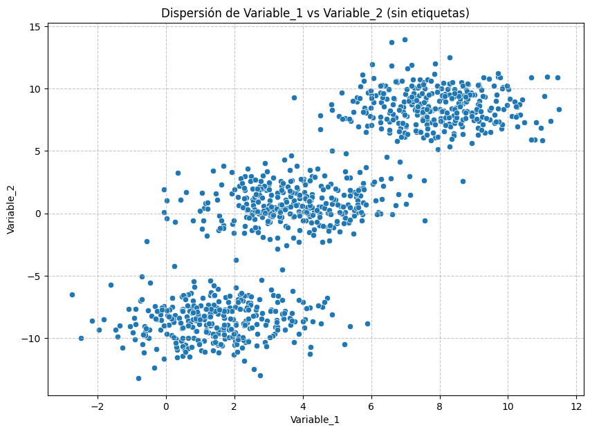

```python
import matplotlib.pyplot as plt
import seaborn as sns

plt.figure(figsize=(10, 7))
sns.scatterplot(x='Variable_1', y='Variable_2', data=df_blobs, palette='viridis', legend=False)
plt.title('Dispersión de Variable_1 vs Variable_2 (sin etiquetas)')
plt.xlabel('Variable_1')
plt.ylabel('Variable_2')
plt.grid(True, linestyle='--', alpha=0.7)
plt.show()
```

### Paso 3: Asignación aleatoria de clusters

#### ¿Qué se va a hacer?

Se asignará a cada dato un cluster de manera aleatoria, sin considerar su posición o características.

#### ¿Por qué y para qué se hace?

Este paso se utiliza como punto de comparación para evaluar posteriormente qué tan bien funcionan los algoritmos de clustering frente a una asignación sin lógica.

#### Resultados

Se agrega una nueva columna llamada `Random_Cluster` al dataset, donde cada valor representa un cluster asignado aleatoriamente (0, 1 o 2).

```python
import numpy as np

# Establecer una semilla para la reproducibilidad
np.random.seed(80)

# Generar asignaciones de cluster aleatorias para cada observación (0, 1, o 2)
# Asegúrate de que el número de muestras sea el mismo que en df_blobs
random_clusters = np.random.randint(0, 3, size=len(df_blobs))

# Añadir esta nueva columna al DataFrame
df_blobs['Random_Cluster'] = random_clusters

# Mostrar las primeras filas del DataFrame actualizado
display(df_blobs.head())
```

|  | Variable_1 | Variable_2 | Target | Random_Cluster |
| --- | --- | --- | --- | --- |
| 0 | 4.218627 | -10.725929 | 0 | 0 |
| 1 | 5.756293 | 2.420053 | 2 | 2 |
| 2 | 2.316034 | 2.979996 | 2 | 2 |
| 3 | 0.478698 | -7.650879 | 0 | 2 |
| 4 | 7.518604 | 6.054857 | 1 | 2 |

### Paso 4: Visualización de clusters aleatorios

#### ¿Qué se va a hacer?

Se graficarán los datos nuevamente, pero ahora coloreando cada punto según el cluster asignado aleatoriamente.

#### ¿Por qué y para qué se hace?

Este paso permite visualizar cómo se comporta una clasificación sin lógica y compararla con la estructura real de los datos.

#### Resultados

Se obtiene una gráfica de dispersión donde los puntos están coloreados según `Random_Cluster`.

A diferencia de la visualización anterior, los colores aparecen mezclados sin formar grupos definidos. Esto indica que la asignación aleatoria no respeta la estructura natural de los datos, lo que refuerza la necesidad de utilizar algoritmos de clustering adecuados.

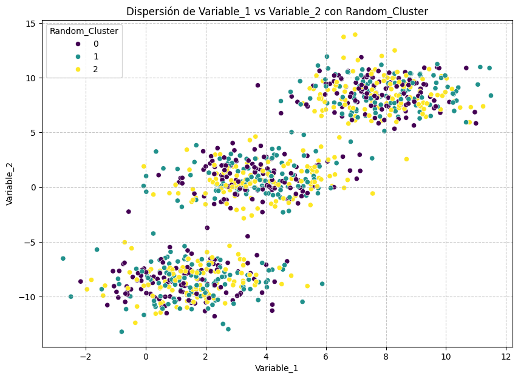

```python
import matplotlib.pyplot as plt
import seaborn as sns

plt.figure(figsize=(10, 7))
sns.scatterplot(x='Variable_1', y='Variable_2', data=df_blobs, hue='Random_Cluster', palette='viridis', legend='full')
plt.title('Dispersión de Variable_1 vs Variable_2 con Random_Cluster')
plt.xlabel('Variable_1')
plt.ylabel('Variable_2')
plt.grid(True, linestyle='--', alpha=0.7)
plt.show()
```

### Paso 5: Cálculo de centroides de clusters aleatorios

#### ¿Qué se va a hacer?

Se calculará el centroide (promedio de las variables) para cada uno de los clusters asignados aleatoriamente.

#### ¿Por qué y para qué se hace?

Este paso permite identificar el punto central de cada grupo, lo cual es fundamental en algoritmos de clustering como K-Means, donde los centroides representan cada cluster.

```python
# Calcular los centroides de cada cluster aleatorio
centroids = df_blobs.groupby('Random_Cluster')[['Variable_1', 'Variable_2']].mean().reset_index()

display(centroids)
```

|  | Random_Cluster | Variable_1 | Variable_2 |
| --- | --- | --- | --- |
| 0 | 0 | 4.227570 | 0.405118 |
| 1 | 1 | 4.335211 | -0.017096 |
| 2 | 2 | 4.413253 | 0.317486 |

### Paso 6: Visualización de centroides en clusters aleatorios

#### ¿Qué se va a hacer?

Se graficarán los datos junto con los centroides calculados para cada cluster aleatorio.

#### ¿Por qué y para qué se hace?

Este paso permite observar la relación entre los centroides y los datos, y evaluar si realmente representan el centro de grupos coherentes.

#### Resultados

Se obtiene una gráfica donde los puntos están coloreados según `Random_Cluster` y los centroides se muestran como marcadores grandes en color rojo.

Se observa que los centroides no se encuentran en el centro de agrupaciones claras, ya que los clusters fueron asignados aleatoriamente. Esto demuestra que, aunque es posible calcular centroides, estos no tienen un significado útil si los datos no están agrupados correctamente.

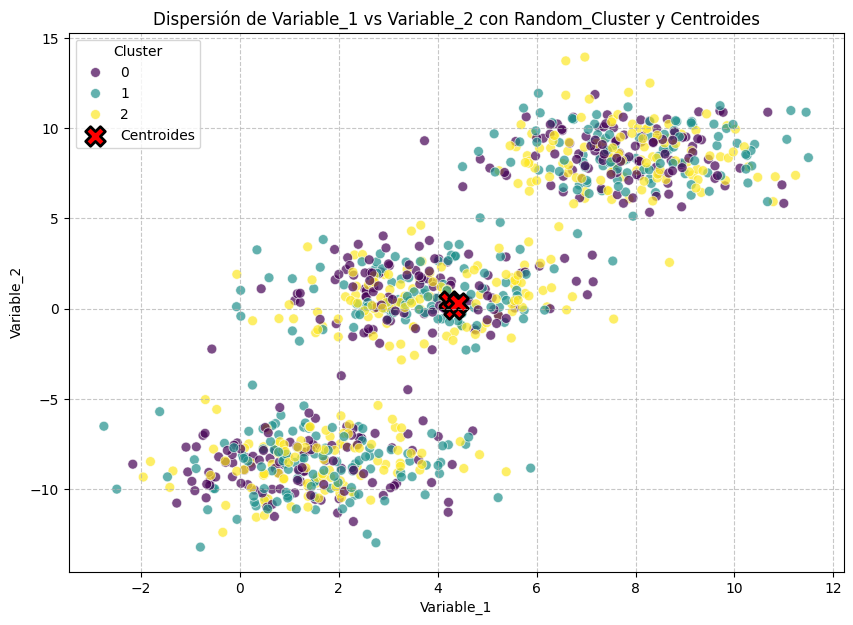

```python
import matplotlib.pyplot as plt
import seaborn as sns

plt.figure(figsize=(10, 7))

# Graficar los puntos de datos con Random_Cluster como hue
sns.scatterplot(x='Variable_1', y='Variable_2', data=df_blobs, hue='Random_Cluster', palette='viridis', legend='full', s=50, alpha=0.7)

# Superponer los centroides
sns.scatterplot(x='Variable_1', y='Variable_2', data=centroids, marker='X', s=200, color='red', edgecolor='black', linewidth=2, label='Centroides')

plt.title('Dispersión de Variable_1 vs Variable_2 con Random_Cluster y Centroides')
plt.xlabel('Variable_1')
plt.ylabel('Variable_2')
plt.grid(True, linestyle='--', alpha=0.7)
plt.legend(title='Cluster')
plt.show()
```

### Paso 7: Reasignación de clusters por distancia a centroides

#### ¿Qué se va a hacer?

Se calculará la distancia de cada punto a los centroides y se reasignará cada dato al cluster cuyo centroide esté más cercano.

#### ¿Por qué y para qué se hace?

Este paso simula el comportamiento de algoritmos como K-Means, donde los puntos se agrupan en función de su cercanía a los centroides, mejorando la coherencia de los clusters.

#### Resultados

Se actualiza la columna `Random_Cluster`, donde ahora cada punto pertenece al cluster del centroide más cercano.

```python
import numpy as np
from scipy.spatial.distance import cdist

# Obtener las coordenadas de los puntos y los centroides
X_points = df_blobs[['Variable_1', 'Variable_2']].values
centroids_coords = centroids[['Variable_1', 'Variable_2']].values

# Calcular la distancia euclidiana de cada punto a cada centroide
distances = cdist(X_points, centroids_coords, metric='euclidean')

# Asignar cada punto al cluster del centroide más cercano
new_random_clusters = np.argmin(distances, axis=1)
df_blobs['Random_Cluster'] = new_random_clusters

# Mostrar las primeras filas del DataFrame actualizado con las nuevas asignaciones
display(df_blobs.head())
```

|  | Variable_1 | Variable_2 | Target | Random_Cluster |
| --- | --- | --- | --- | --- |
| 0 | 4.218627 | -10.725929 | 0 | 1 |
| 1 | 5.756293 | 2.420053 | 2 | 2 |
| 2 | 2.316034 | 2.979996 | 2 | 0 |
| 3 | 0.478698 | -7.650879 | 0 | 1 |
| 4 | 7.518604 | 6.054857 | 1 | 2 |

### Paso 8: Actualización de centroides

#### ¿Qué se va a hacer?

Se recalcularán los centroides tomando en cuenta las nuevas asignaciones de los datos a cada cluster.

#### ¿Por qué y para qué se hace?

Este paso permite ajustar la posición de los centroides para que representen mejor a los grupos actuales. Es parte del proceso iterativo de algoritmos como K-Means.

```python
# Calcular los nuevos centroides basados en las nuevas asignaciones de cluster
centroids = df_blobs.groupby('Random_Cluster')[['Variable_1', 'Variable_2']].mean().reset_index()

display(centroids)
```

|  | Random_Cluster | Variable_1 | Variable_2 |
| --- | --- | --- | --- |
| 0 | 0 | 5.065979 | 5.296944 |
| 1 | 1 | 1.871701 | -7.027321 |
| 2 | 2 | 8.063286 | 5.932985 |

### Paso 9: Visualización de nuevas asignaciones y centroides

#### ¿Qué se va a hacer?

Se graficarán los datos utilizando las nuevas asignaciones de cluster junto con los centroides actualizados.

#### ¿Por qué y para qué se hace?

Este paso permite evaluar visualmente si los clusters y sus centroides representan mejor la estructura real de los datos después de la reasignación.

#### Resultados

Se obtiene una gráfica de dispersión donde los puntos están coloreados según las nuevas asignaciones de `Random_Cluster` y los centroides se muestran como marcadores grandes.

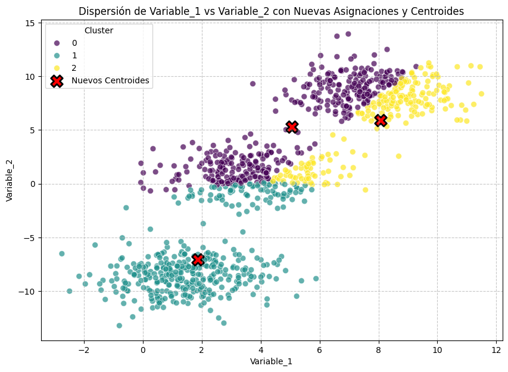

```python
import matplotlib.pyplot as plt
import seaborn as sns

plt.figure(figsize=(10, 7))

# Graficar los puntos de datos con las nuevas asignaciones de Random_Cluster como hue
sns.scatterplot(x='Variable_1', y='Variable_2', data=df_blobs, hue='Random_Cluster', palette='viridis', legend='full', s=50, alpha=0.7)

# Superponer los nuevos centroides
sns.scatterplot(x='Variable_1', y='Variable_2', data=centroids, marker='X', s=200, color='red', edgecolor='black', linewidth=2, label='Nuevos Centroides')

plt.title('Dispersión de Variable_1 vs Variable_2 con Nuevas Asignaciones y Centroides')
plt.xlabel('Variable_1')
plt.ylabel('Variable_2')
plt.grid(True, linestyle='--', alpha=0.7)
plt.legend(title='Cluster')
plt.show()
```

### Paso 10: Carga del dataset NCI60

#### ¿Qué se va a hacer?

Se cargará el dataset NCI60, el cual contiene datos reales de expresión genética junto con sus etiquetas correspondientes.

#### ¿Por qué y para qué se hace?

Este paso permite trabajar con un conjunto de datos real, lo que ayuda a aplicar y evaluar técnicas de clustering en un contexto más complejo y significativo que los datos artificiales.

#### Resultados

Se obtiene un dataset con dos componentes principales:

- **X**: matriz de datos con múltiples variables (genes).
- **y**: etiquetas que indican el tipo de cáncer asociado a cada muestra.

Se muestra la forma de los datos, indicando el número de muestras y variables, así como la cantidad de etiquetas.

También se presenta el conteo de cada tipo de etiqueta, lo que permite observar la distribución de las clases dentro del dataset. Esto es útil para entender la diversidad y el balance de los datos antes de aplicar cualquier algoritmo de análisis.

```python
!pip install ISLP
```

```python
import ISLP as islp
import pandas as pd

# Cargar el dataset NCI60
nci60_dataset = islp.load_data('NCI60')

# Asignar los datos y las etiquetas desde el objeto cargado
X_nci60 = nci60_dataset['data']
y_nci60 = nci60_dataset['labels'] # Access 'labels' key for labels

print('Shape of NCI60 data (X):', X_nci60.shape)
print('Shape of NCI60 labels (y):', y_nci60.shape)

# Contar las ocurrencias de cada tipo de etiqueta
print('\nCounts of labels (y):')
display(y_nci60['label'].value_counts())
```

```
Shape of NCI60 data (X): (64, 6830)
Shape of NCI60 labels (y): (64, 1)

Counts of labels (y):
```

| label | count |
| --- | --- |
| RENAL | 9 |
| NSCLC | 9 |
| MELANOMA | 8 |
| BREAST | 7 |
| COLON | 7 |
| OVARIAN | 6 |
| LEUKEMIA | 6 |
| CNS | 5 |
| PROSTATE | 2 |
| UNKNOWN | 1 |
| K562B-repro | 1 |
| K562A-repro | 1 |
| MCF7A-repro | 1 |
| MCF7D-repro | 1 |

**dtype:** int64

```python
from sklearn.cluster import KMeans
import matplotlib.pyplot as plt
import seaborn as sns
import numpy as np
```

### Paso 11: Aplicación de K-Means

#### ¿Qué se va a hacer?

Se aplicará el algoritmo K-Means al dataset NCI60 para agrupar los datos en 3 clusters.

#### ¿Por qué y para qué se hace?

Este paso permite identificar patrones o agrupaciones dentro de los datos sin utilizar las etiquetas reales, lo que es útil para descubrir estructuras ocultas en datasets complejos como los de expresión genética.

#### Resultados

El modelo de K-Means se entrena correctamente y genera:

- Etiquetas de cluster para cada muestra (`cluster_labels`).
- Los centroides de cada cluster (`cluster_centers`).

Se confirma que se formaron 3 clusters, lo que indica que el algoritmo logró dividir los datos en tres grupos distintos basados en sus características.

```python
# Realizar K-Means con 3 clusters y n_init=20
kmeans = KMeans(n_clusters=3, n_init=20, random_state=42)
kmeans.fit(X_nci60)

# Obtener las etiquetas de cluster y los centroides
cluster_labels = kmeans.labels_
cluster_centers = kmeans.cluster_centers_

print(f"Se encontraron {kmeans.n_clusters} clusters.")
```

```
Se encontraron 3 clusters.
```

### Paso 12: Preparación de datos para visualización

#### ¿Qué se va a hacer?

Se crearán DataFrames para visualizar los datos del clustering, utilizando únicamente las primeras dos características y sus respectivos centroides.

#### ¿Por qué y para qué se hace?

Este paso permite representar los datos en un plano bidimensional, facilitando la interpretación visual de los clusters generados por K-Means.

#### Resultados

Se obtienen dos tablas:

Primeras filas de los datos con clusters asignados:

| Feature_0 | Feature_1 | Cluster |
| --- | --- | --- |
| 0.300000 | 1.180000 | 0 |
| 0.679961 | 1.289961 | 0 |
| 0.940000 | -0.040000 | 0 |
| 0.280000 | -0.310000 | 0 |
| 0.485000 | -0.465000 | 0 |

Centroides de los clusters:

| Feature_0 | Feature_1 | Cluster |
| --- | --- | --- |
| 0.066571 | 0.052285 | 0 |
| -0.173001 | -0.140000 | 1 |
| -0.010002 | -0.090002 | 2 |

Estos resultados permiten observar la ubicación de los datos y los centroides en un espacio reducido, facilitando el análisis visual de la agrupación generada por el algoritmo.

```python
# Crear un DataFrame para visualizar los datos con las etiquetas de cluster
df_nci60_clustered = pd.DataFrame(X_nci60[:, :2], columns=['Feature_0', 'Feature_1']) # Usar solo las primeras 2 características para la visualización
df_nci60_clustered['Cluster'] = cluster_labels

# Crear un DataFrame para los centroides (solo las 2 primeras características)
df_centroids = pd.DataFrame(cluster_centers[:, :2], columns=['Feature_0', 'Feature_1'])
df_centroids['Cluster'] = np.arange(kmeans.n_clusters)

display(df_nci60_clustered.head())
display(df_centroids.head())
```

|  | Feature_0 | Feature_1 | Cluster |
| --- | --- | --- | --- |
| 0 | 0.300000 | 1.180000 | 0 |
| 1 | 0.679961 | 1.289961 | 0 |
| 2 | 0.940000 | -0.040000 | 0 |
| 3 | 0.280000 | -0.310000 | 0 |
| 4 | 0.485000 | -0.465000 | 0 |

|  | Feature_0 | Feature_1 | Cluster |
| --- | --- | --- | --- |
| 0 | 0.066571 | 0.052285 | 0 |
| 1 | -0.173001 | -0.140000 | 1 |
| 2 | -0.010002 | -0.090002 | 2 |

### Paso 13: Visualización de clusters de NCI60

#### ¿Qué se va a hacer?

Se graficarán los datos del dataset NCI60 utilizando las dos primeras características, mostrando los clusters generados por K-Means junto con sus centroides.

#### ¿Por qué y para qué se hace?

Este paso permite analizar visualmente cómo el algoritmo agrupó los datos y verificar si los centroides representan adecuadamente el centro de cada cluster.

#### Resultados

Se obtiene una gráfica de dispersión donde los puntos están coloreados según el cluster asignado y los centroides se muestran como marcadores destacados.

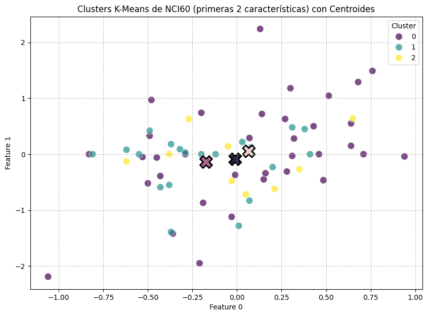

```python
# Visualizar los clusters y los centroides
plt.figure(figsize=(10, 7))
sns.scatterplot(x='Feature_0', y='Feature_1', hue='Cluster', data=df_nci60_clustered, palette='viridis', legend='full', s=100, alpha=0.7)
sns.scatterplot(x='Feature_0', y='Feature_1', hue='Cluster', data=df_centroids, marker='X', s=300, color='red', edgecolor='black', linewidth=2, legend=False)

plt.title('Clusters K-Means de NCI60 (primeras 2 características) con Centroides')
plt.xlabel('Feature 0')
plt.ylabel('Feature 1')
plt.grid(True, linestyle='--', alpha=0.7)
plt.show()
```

### Paso 14: Reducción de dimensionalidad con PCA

#### ¿Qué se va a hacer?

Se aplicará PCA (Análisis de Componentes Principales) al dataset NCI60 para transformar los datos a un nuevo espacio de menor dimensionalidad.

#### ¿Por qué y para qué se hace?

Este paso permite reducir la complejidad del dataset manteniendo la mayor cantidad de información posible, facilitando su análisis y visualización.

#### Resultados

Se obtienen datos transformados en un nuevo espacio de componentes principales:

```python
from sklearn.decomposition import PCA

# Realizar PCA en los datos X_nci60
# Establecemos n_components=None para obtener todas las componentes posibles
pca = PCA(n_components=None, random_state=42)
pca.fit(X_nci60)

# Transformar los datos
X_pca = pca.transform(X_nci60)

print(f"Dimensiones de los datos originales: {X_nci60.shape}")
print(f"Dimensiones de los datos transformados por PCA: {X_pca.shape}")
```

```
Dimensiones de los datos originales: (64, 6830)
Dimensiones de los datos transformados por PCA: (64, 64)
```

## Paso 15: Preparación de datos con componentes principales

#### ¿Qué se va a hacer?

Se creará un DataFrame utilizando las primeras tres componentes principales obtenidas con PCA, junto con las etiquetas de cluster.

#### ¿Por qué y para qué se hace?

Este paso permite trabajar con una versión reducida de los datos que conserva la mayor parte de la información, facilitando su análisis y visualización.

#### Resultados

Se obtiene un nuevo DataFrame con las componentes principales y el cluster asignado

### Paso 15: Preparación de datos con componentes principales

#### ¿Qué se va a hacer?

Se creará un DataFrame con las primeras tres componentes principales obtenidas mediante PCA, junto con las etiquetas de cluster.

#### ¿Por qué y para qué se hace?

Este paso permite reducir la dimensionalidad de los datos y trabajar con variables más representativas, facilitando la visualización y el análisis de los clusters.

#### Resultados

Se obtiene un DataFrame con las componentes principales y el cluster asignado

```python
import pandas as pd

# Crear un DataFrame con las primeras 3 componentes principales y las etiquetas de cluster
df_pca = pd.DataFrame(X_pca[:, :3], columns=['PC1', 'PC2', 'PC3'])
df_pca['Cluster'] = cluster_labels

display(df_pca.head())
```

|  | PC1 | PC2 | PC3 | Cluster |
| --- | --- | --- | --- | --- |
| 0 | 19.795782 | 0.115269 | -5.968917 | 0 |
| 1 | 21.546101 | -1.457350 | -9.019584 | 0 |
| 2 | 25.056621 | 1.526093 | -6.959653 | 0 |
| 3 | 37.409536 | -11.389478 | -5.407097 | 0 |
| 4 | 50.218642 | -1.346174 | -17.599944 | 0 |

### Paso 16: Visualización de clusters con PCA

#### ¿Qué se va a hacer?

Se graficarán las dos primeras componentes principales (PC1 y PC2), mostrando los clusters obtenidos por K-Means.

#### ¿Por qué y para qué se hace?

Este paso permite visualizar los datos en un espacio reducido donde se conserva la mayor parte de la información, facilitando la identificación de patrones y la separación entre clusters.

#### Resultados

Se obtiene una gráfica de dispersión donde los puntos están coloreados según el cluster asignado.

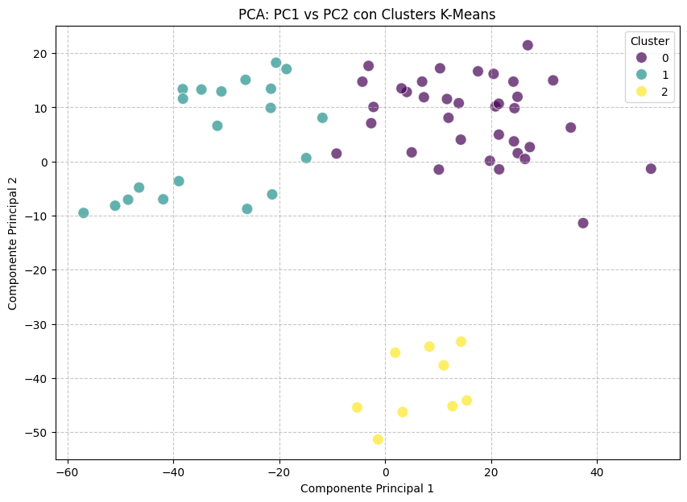

```python
import matplotlib.pyplot as plt
import seaborn as sns

plt.figure(figsize=(10, 7))
sns.scatterplot(x='PC1', y='PC2', hue='Cluster', data=df_pca, palette='viridis', legend='full', s=100, alpha=0.7)
plt.title('PCA: PC1 vs PC2 con Clusters K-Means')
plt.xlabel('Componente Principal 1')
plt.ylabel('Componente Principal 2')
plt.grid(True, linestyle='--', alpha=0.7)
plt.show()
```

### Paso 17: Visualización de clusters con PC1 y PC3

#### ¿Qué se va a hacer?

Se graficarán la primera y la tercera componente principal (PC1 y PC3), mostrando los clusters generados por K-Means.

#### ¿Por qué y para qué se hace?

Este paso permite analizar la separación de los clusters desde otra perspectiva, ya que diferentes combinaciones de componentes pueden revelar estructuras distintas en los datos.

#### Resultados

Se obtiene una gráfica de dispersión donde los puntos están coloreados según el cluster asignado.

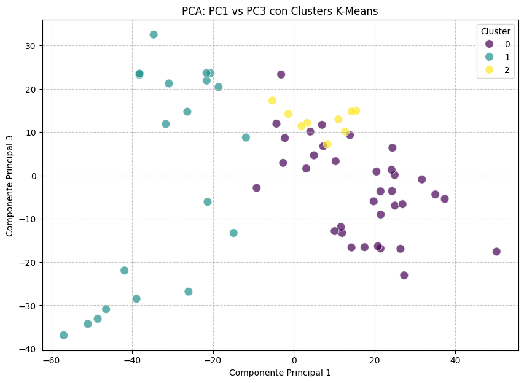

```python
import matplotlib.pyplot as plt
import seaborn as sns

plt.figure(figsize=(10, 7))
sns.scatterplot(x='PC1', y='PC3', hue='Cluster', data=df_pca, palette='viridis', legend='full', s=100, alpha=0.7)
plt.title('PCA: PC1 vs PC3 con Clusters K-Means')
plt.xlabel('Componente Principal 1')
plt.ylabel('Componente Principal 3')
plt.grid(True, linestyle='--', alpha=0.7)
plt.show()
```

### Paso 18: Visualización de clusters con PC2 y PC3

#### ¿Qué se va a hacer?

Se graficarán la segunda y la tercera componente principal (PC2 y PC3), mostrando los clusters obtenidos por K-Means.

#### ¿Por qué y para qué se hace?

Este paso permite explorar otra combinación de componentes principales para analizar cómo se distribuyen los clusters en diferentes proyecciones del espacio reducido.

#### Resultados

Se obtiene una gráfica de dispersión donde los puntos están coloreados según el cluster asignado.

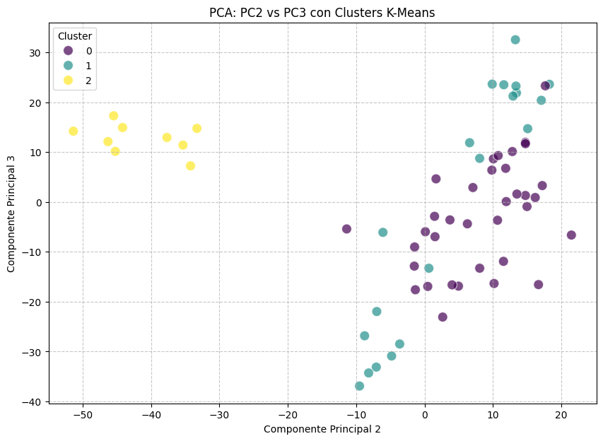

```python
import matplotlib.pyplot as plt
import seaborn as sns

plt.figure(figsize=(10, 7))
sns.scatterplot(x='PC2', y='PC3', hue='Cluster', data=df_pca, palette='viridis', legend='full', s=100, alpha=0.7)
plt.title('PCA: PC2 vs PC3 con Clusters K-Means')
plt.xlabel('Componente Principal 2')
plt.ylabel('Componente Principal 3')
plt.grid(True, linestyle='--', alpha=0.7)
plt.show()
```

### Paso 19: Análisis de varianza explicada

#### ¿Qué se va a hacer?

Se graficará la varianza explicada por cada componente principal y la varianza acumulada.

#### ¿Por qué y para qué se hace?

Este paso permite identificar cuántas componentes principales son necesarias para representar la mayor parte de la información del dataset, ayudando a reducir dimensionalidad de forma eficiente.

#### Resultados

Se obtiene una gráfica con dos elementos:

- Barras que representan la varianza explicada por cada componente individual.
- Una línea que muestra la varianza acumulada.

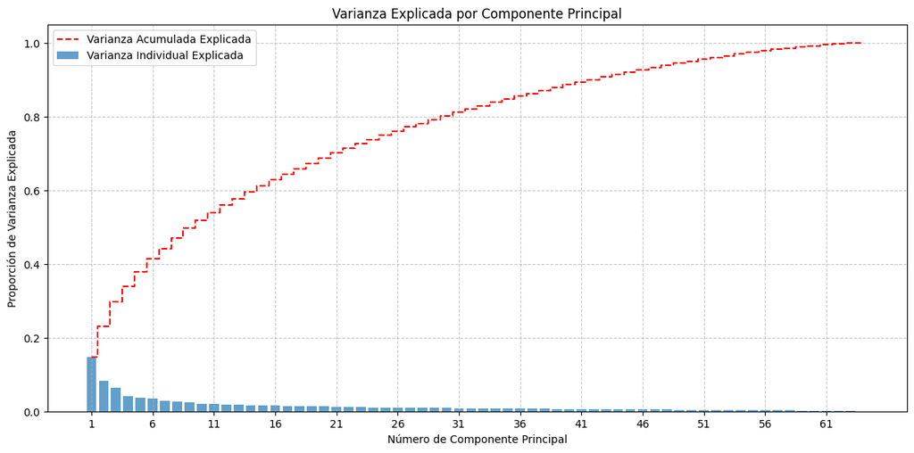

```python
import matplotlib.pyplot as plt
import numpy as np

# Varianza explicada por cada componente
explained_variance_ratio = pca.explained_variance_ratio_
cumulative_explained_variance = np.cumsum(explained_variance_ratio)

plt.figure(figsize=(12, 6))

plt.bar(range(1, len(explained_variance_ratio) + 1), explained_variance_ratio, alpha=0.7, align='center', label='Varianza Individual Explicada')
plt.step(range(1, len(cumulative_explained_variance) + 1), cumulative_explained_variance, where='mid', label='Varianza Acumulada Explicada', color='red', linestyle='--')

plt.title('Varianza Explicada por Componente Principal')
plt.xlabel('Número de Componente Principal')
plt.ylabel('Proporción de Varianza Explicada')
plt.xticks(range(1, len(explained_variance_ratio) + 1, 5)) # Mostrar ticks cada 5 componentes
plt.grid(True, linestyle='--', alpha=0.7)
plt.legend()
plt.tight_layout()
plt.show()
```

### K-Means Clustering con los Primeros 3 Componentes Principales

### Paso 20: K-Means sobre datos reducidos con PCA

#### ¿Qué se va a hacer?

Se aplicará el algoritmo K-Means utilizando únicamente las primeras tres componentes principales obtenidas con PCA.

#### ¿Por qué y para qué se hace?

Este paso permite realizar clustering sobre una versión reducida del dataset, lo que disminuye la complejidad computacional y puede mejorar la separación de los datos al eliminar ruido y redundancia.

#### Resultados

El modelo K-Means se entrena utilizando los datos transformados por PCA y genera nuevas etiquetas de cluster.

Se confirma que se formaron 3 clusters, y se obtiene un nuevo DataFrame con las componentes principales y el cluster asignado.

Estos resultados permiten comparar el clustering realizado sobre los datos originales con el realizado sobre los datos reducidos, evaluando si la reducción de dimensionalidad mantiene la estructura de los grupos.

```python
from sklearn.cluster import KMeans
import pandas as pd
import matplotlib.pyplot as plt
import seaborn as sns

# Seleccionar los primeros 3 componentes principales para el clustering
X_pca_3_components = X_pca[:, :3]

# Realizar K-Means con 3 clusters (igual que antes) y n_init=20
kmeans_pca = KMeans(n_clusters=3, n_init=20, random_state=42)
kmeans_pca.fit(X_pca_3_components)

# Obtener las etiquetas de cluster
cluster_labels_pca = kmeans_pca.labels_

print(f"Se encontraron {kmeans_pca.n_clusters} clusters usando los 3 primeros componentes principales.")

# Crear un DataFrame para visualizar con las etiquetas de cluster
df_pca_clustered = pd.DataFrame(X_pca_3_components, columns=['PC1', 'PC2', 'PC3'])
df_pca_clustered['Cluster'] = cluster_labels_pca

display(df_pca_clustered.head())
```

```
Se encontraron 3 clusters usando los 3 primeros componentes principales.
```

|  | PC1 | PC2 | PC3 | Cluster |
| --- | --- | --- | --- | --- |
| 0 | 19.795782 | 0.115269 | -5.968917 | 1 |
| 1 | 21.546101 | -1.457350 | -9.019584 | 1 |
| 2 | 25.056621 | 1.526093 | -6.959653 | 1 |
| 3 | 37.409536 | -11.389478 | -5.407097 | 1 |
| 4 | 50.218642 | -1.346174 | -17.599944 | 1 |

### Visualización de Clusters en los Componentes Principales

### Paso 21: Visualización de clusters con PCA (K-Means)

#### ¿Qué se va a hacer?

Se generarán tres gráficas de dispersión utilizando diferentes combinaciones de componentes principales (PC1 vs PC2, PC1 vs PC3 y PC2 vs PC3) para visualizar los clusters obtenidos con K-Means.

#### ¿Por qué y para qué se hace?

Este paso permite analizar cómo se distribuyen los clusters en distintas proyecciones del espacio reducido, facilitando la interpretación de los resultados del clustering.

#### Resultados

Se obtienen tres visualizaciones:

- **PC1 vs PC2**: Muestra generalmente la mejor separación entre clusters, ya que estas componentes capturan la mayor varianza.
- **PC1 vs PC3**: Permite observar diferencias adicionales entre grupos que no son evidentes en las primeras dos componentes.
- **PC2 vs PC3**: Puede mostrar mayor solapamiento, indicando que estas componentes contienen menor información discriminativa.

En conjunto, las gráficas permiten confirmar que el clustering sobre los datos reducidos mantiene una estructura coherente, aunque algunas separaciones pueden no ser perfectamente claras debido a la reducción de dimensionalidad.

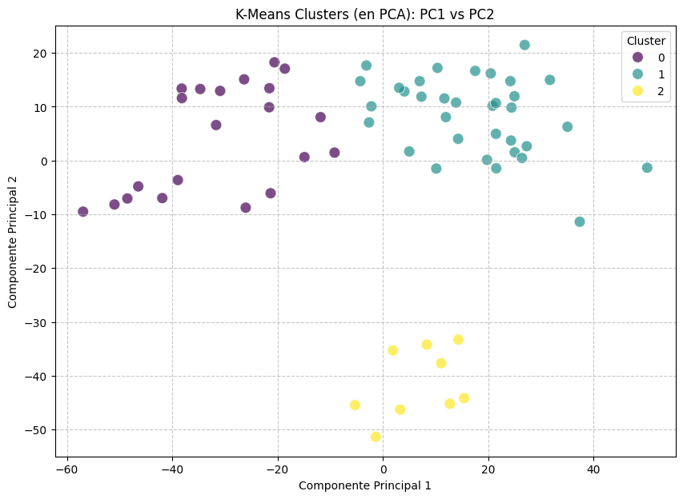

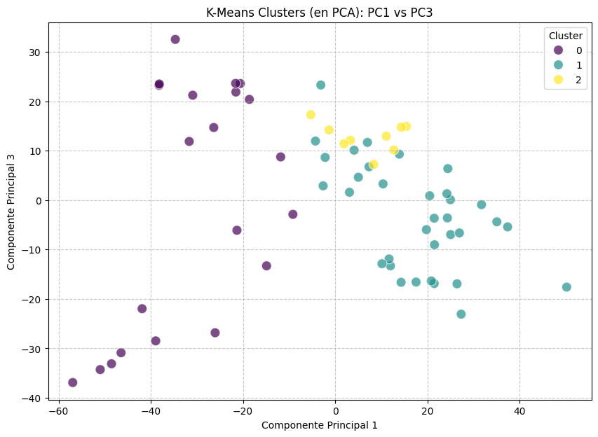

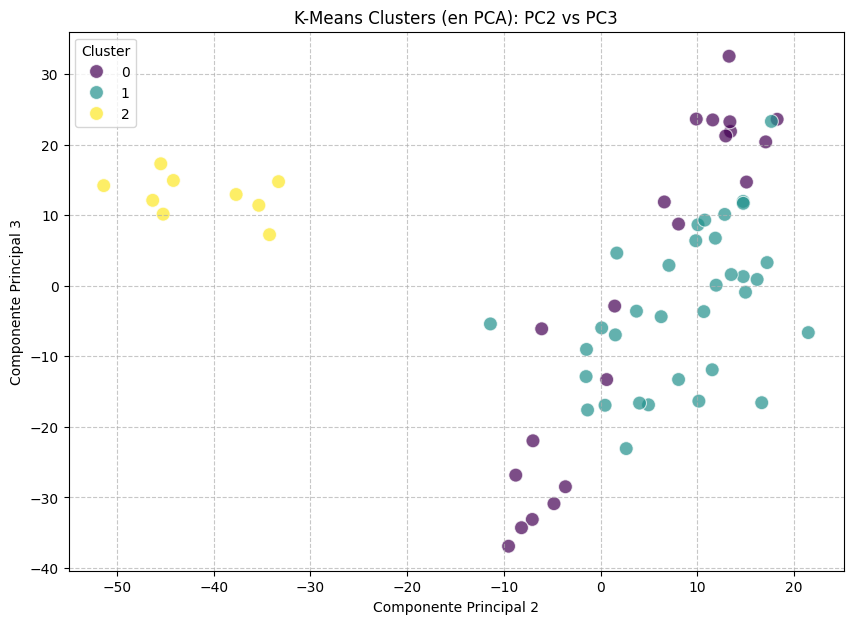

```python
# PC1 vs PC2
plt.figure(figsize=(10, 7))
sns.scatterplot(x='PC1', y='PC2', hue='Cluster', data=df_pca_clustered, palette='viridis', legend='full', s=100, alpha=0.7)
plt.title('K-Means Clusters (en PCA): PC1 vs PC2')
plt.xlabel('Componente Principal 1')
plt.ylabel('Componente Principal 2')
plt.grid(True, linestyle='--', alpha=0.7)
plt.show()

# PC1 vs PC3
plt.figure(figsize=(10, 7))
sns.scatterplot(x='PC1', y='PC3', hue='Cluster', data=df_pca_clustered, palette='viridis', legend='full', s=100, alpha=0.7)
plt.title('K-Means Clusters (en PCA): PC1 vs PC3')
plt.xlabel('Componente Principal 1')
plt.ylabel('Componente Principal 3')
plt.grid(True, linestyle='--', alpha=0.7)
plt.show()

# PC2 vs PC3
plt.figure(figsize=(10, 7))
sns.scatterplot(x='PC2', y='PC3', hue='Cluster', data=df_pca_clustered, palette='viridis', legend='full', s=100, alpha=0.7)
plt.title('K-Means Clusters (en PCA): PC2 vs PC3')
plt.xlabel('Componente Principal 2')
plt.ylabel('Componente Principal 3')
plt.grid(True, linestyle='--', alpha=0.7)
plt.show()
```

### Paso 22: Evaluación del clustering con tabla de contingencia

#### ¿Qué se va a hacer?

Se construirá una tabla de contingencia que compara las clases originales del dataset con los clusters generados por K-Means usando PCA.

#### ¿Por qué y para qué se hace?

Este paso permite evaluar qué tan bien el algoritmo de clustering logra agrupar datos que pertenecen a la misma clase real, aun cuando el modelo no utiliza esas etiquetas durante el entrenamiento.

#### Resultados

Se obtiene una tabla donde:

- Las filas representan las clases originales.
- Las columnas representan los clusters asignados por K-Means.

Cada celda indica cuántos elementos de una clase fueron asignados a un cluster específico.

Si el clustering es bueno, se observará que cada clase se concentra principalmente en un solo cluster. Si los valores están muy dispersos entre varios clusters, indica que el modelo no logró separar adecuadamente las clases.

Esta tabla permite analizar la calidad del clustering de manera más objetiva.

```python
import pandas as pd
import numpy as np

# Crear la tabla de contingencia
# Usamos y_nci60['label'] que contiene las clases originales y cluster_labels_pca para los clusters asignados
contingency_table = pd.crosstab(y_nci60['label'], cluster_labels_pca, rownames=['Clase Original'], colnames=['Cluster K-Means (PCA)'])

print("Tabla de Contingencia (Clases originales vs. Clusters K-Means (PCA)):\n")
display(contingency_table)
```

```
Tabla de Contingencia (Clases originales vs. Clusters K-Means (PCA)):
```

| Cluster K-Means (PCA) Clase Original | 0 | 1 | 2 |
| --- | --- | --- | --- |
| BREAST | 2 | 3 | 2 |
| CNS | 0 | 5 | 0 |
| COLON | 7 | 0 | 0 |
| K562A-repro | 1 | 0 | 0 |
| K562B-repro | 1 | 0 | 0 |
| LEUKEMIA | 6 | 0 | 0 |
| MCF7A-repro | 1 | 0 | 0 |
| MCF7D-repro | 1 | 0 | 0 |
| MELANOMA | 0 | 1 | 7 |
| NSCLC | 2 | 7 | 0 |
| OVARIAN | 0 | 6 | 0 |
| PROSTATE | 0 | 2 | 0 |
| RENAL | 0 | 9 | 0 |
| UNKNOWN | 0 | 1 | 0 |

### Paso 23: Análisis de genes diferenciales con heatmap

#### ¿Qué se va a hacer?

Se seleccionarán dos clusters y se identificarán los genes con mayor diferencia de expresión entre ellos, para posteriormente visualizarlos en un heatmap.

#### ¿Por qué y para qué se hace?

Este paso permite entender qué variables (genes) son más relevantes para distinguir entre clusters, lo cual es especialmente útil en datos biológicos donde se busca interpretar diferencias entre grupos.

#### Resultados

Se obtiene un heatmap que muestra la expresión genética promedio (estandarizada) de los genes más diferenciales entre los dos clusters seleccionados.

- Cada fila representa un gen.
- Cada columna representa un cluster.
- Los colores indican el nivel de expresión (mayor o menor).

```
Preparando heatmap para la comparación entre el Cluster 0 y el Cluster 1...

Heatmap de los 40 genes más relevantes entre el Cluster 0 y el Cluster 1:
```

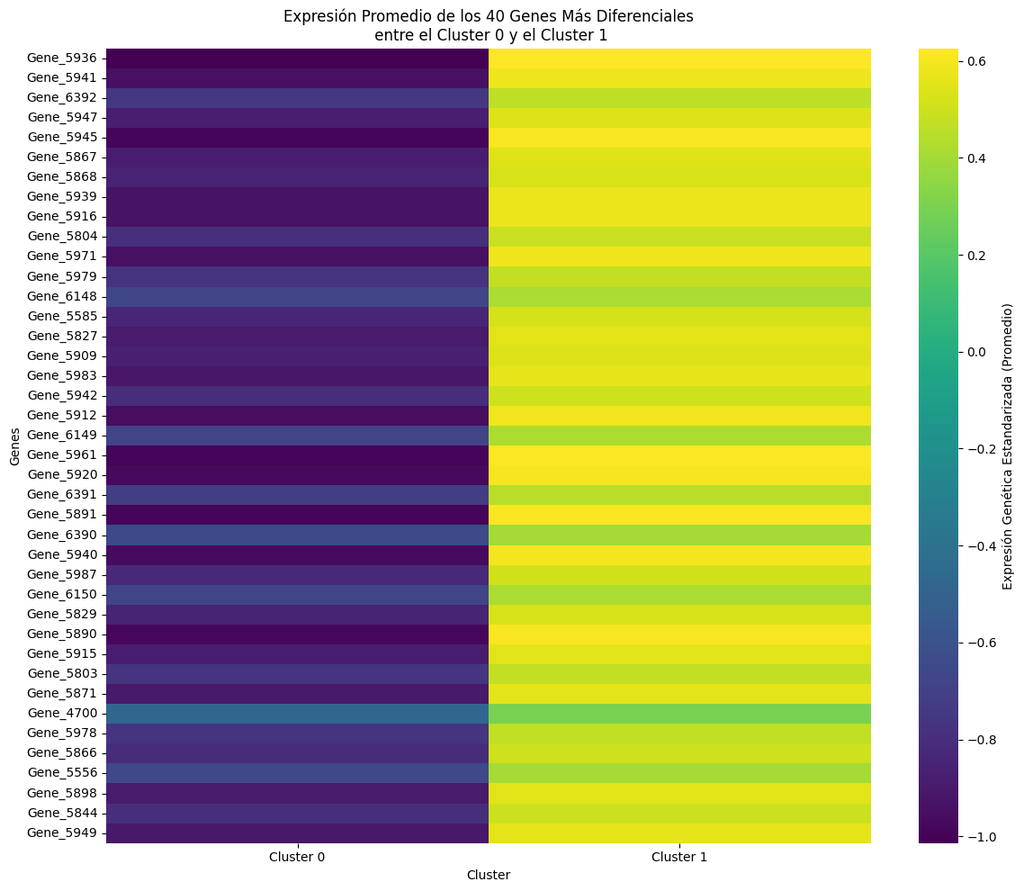

```python
import seaborn as sns
import matplotlib.pyplot as plt
from sklearn.preprocessing import StandardScaler

# --- Configuración para la selección de clusters y genes ---
# Seleccionar dos clusters para comparar. Aquí se eligen el Cluster 0 y el Cluster 1 como ejemplo.
# Puedes modificar estos IDs de cluster según lo que sea más interesante en la tabla de contingencia.
cluster_id_1 = 0
cluster_id_2 = 1
num_top_genes = 40 # Cantidad de genes a seleccionar para el heatmap (entre 30 y 50)

print(f"Preparando heatmap para la comparación entre el Cluster {cluster_id_1} y el Cluster {cluster_id_2}...")

# 1. Obtener los índices de las observaciones que pertenecen a los clusters seleccionados
indices_cluster1 = np.where(cluster_labels_pca == cluster_id_1)[0]
indices_cluster2 = np.where(cluster_labels_pca == cluster_id_2)[0]

# 2. Filtrar los datos de expresión genética (X_nci60) para estas observaciones
X_nci60_cluster1 = X_nci60[indices_cluster1, :]
X_nci60_cluster2 = X_nci60[indices_cluster2, :]

# 3. Calcular la expresión promedio de cada gen en cada uno de los clusters seleccionados
mean_expr_cluster1 = np.mean(X_nci60_cluster1, axis=0)
mean_expr_cluster2 = np.mean(X_nci60_cluster2, axis=0)

# 4. Calcular la diferencia absoluta de la expresión promedio entre los dos clusters para cada gen
diff_expr = np.abs(mean_expr_cluster1 - mean_expr_cluster2)

# Crear nombres genéricos para los genes ya que el dataset original no los tiene
gene_names = [f'Gene_{i}' for i in range(X_nci60.shape[1])]
diff_series = pd.Series(diff_expr, index=gene_names)

# 5. Seleccionar los `num_top_genes` genes con la mayor diferencia absoluta
top_genes_names = diff_series.nlargest(num_top_genes).index.tolist()

# Obtener los índices de columna de estos genes en el array original X_nci60
top_genes_indices = [gene_names.index(g_name) for g_name in top_genes_names]

# 6. Extraer los datos de expresión para estos genes y para las observaciones de los clusters seleccionados
# Concatenar los índices de las observaciones para ambos clusters
all_selected_indices = np.concatenate((indices_cluster1, indices_cluster2))

# Extraer las expresiones de los top genes para las observaciones seleccionadas
data_for_heatmap = X_nci60[all_selected_indices, :][:, top_genes_indices]

# Extraer las etiquetas de cluster correspondientes para estas observaciones
labels_for_heatmap = cluster_labels_pca[all_selected_indices]

# 7. Estandarizar los datos de expresión de los genes seleccionados
scaler = StandardScaler()
scaled_data_for_heatmap = scaler.fit_transform(data_for_heatmap)

# 8. Crear un DataFrame para la visualización del heatmap
df_heatmap = pd.DataFrame(scaled_data_for_heatmap, columns=top_genes_names)
df_heatmap['Cluster'] = labels_for_heatmap

# 9. Ordenar el DataFrame por Cluster para una mejor visualización en el heatmap
df_heatmap_sorted = df_heatmap.sort_values(by='Cluster').reset_index(drop=True)

# Para el heatmap, queremos los genes en el eje Y y las observaciones en el eje X,
# con las observaciones agrupadas por cluster. Podemos usar el Cluster como 'row_colors' o similar en herramientas más avanzadas,
# pero para sns.heatmap, lo transponemos para tener los genes en el eje Y.

# Creamos una 'Annotated Heatmap' si necesitamos más detalles
# Para simplificar, agrupamos y promediamos por cluster para visualizar la tendencia general, o mostramos por observación individual.
# La solicitud pide 'agrupa por cluster y grafica el heatmap', lo cual sugiere una media por cluster.

# Calcular la expresión promedio estandarizada para los top genes en cada cluster seleccionado
mean_scaled_expr_by_cluster = df_heatmap_sorted.groupby('Cluster')[top_genes_names].mean()

print(f"\nHeatmap de los {num_top_genes} genes más relevantes entre el Cluster {cluster_id_1} y el Cluster {cluster_id_2}:\n")
plt.figure(figsize=(12, 10))
sns.heatmap(mean_scaled_expr_by_cluster.T, cmap='viridis', annot=False, fmt=".2f",
            cbar_kws={'label': 'Expresión Genética Estandarizada (Promedio)'})
plt.title(f'Expresión Promedio de los {num_top_genes} Genes Más Diferenciales\n entre el Cluster {cluster_id_1} y el Cluster {cluster_id_2}')
plt.xlabel('Cluster')
plt.ylabel('Genes')
plt.xticks(ticks=[0.5, 1.5], labels=[f'Cluster {cluster_id_1}', f'Cluster {cluster_id_2}']) # Ajustar etiquetas de x para clusters
plt.tight_layout()
plt.show()
```

## C3.4 Hierarchical Clustering

### Paso 1: Carga del dataset para clustering jerárquico

#### ¿Qué se va a hacer?

Se cargará el dataset NCI60 para utilizarlo en un análisis de clustering jerárquico.

#### ¿Por qué y para qué se hace?

Este paso permite trabajar con datos reales de expresión genética, los cuales serán utilizados para identificar agrupaciones mediante métodos jerárquicos.

#### Resultados

Se obtiene el dataset dividido en:

- **X**: matriz de datos con múltiples variables (genes).
- **y**: etiquetas correspondientes a cada muestra.

También se muestran las dimensiones de ambos:

- Datos (X): número de muestras y variables.
- Etiquetas (y): número de muestras etiquetadas.

Esto confirma que los datos están correctamente cargados y listos para el análisis de clustering jerárquico.

```python
import ISLP as islp

# Cargar el dataset NCI60
nci60_dataset = islp.load_data('NCI60')

# Asignar los datos y las etiquetas desde el objeto cargado
X_nci60_hierarchical = nci60_dataset['data']
y_nci60_hierarchical = nci60_dataset['labels']

print('Shape of NCI60 data for hierarchical clustering (X):', X_nci60_hierarchical.shape)
print('Shape of NCI60 labels for hierarchical clustering (y):', y_nci60_hierarchical.shape)
```

```
Shape of NCI60 data for hierarchical clustering (X): (64, 6830)
Shape of NCI60 labels for hierarchical clustering (y): (64, 1)
```

### PCA de los datos NCI60

Como se mencionó anteriormente, el análisis de componentes principales (PCA) ya se realizó en el conjunto de datos `X_nci60` (que es idéntico a `X_nci60_hierarchical`). Los resultados se encuentran en la variable `X_pca`.

A continuación, se muestra una visualización de los dos primeros componentes principales (PC1 vs PC2) para observar la estructura de los datos en un espacio bidimensional reducido.

### Paso 2: Visualización inicial con PCA

#### ¿Qué se va a hacer?

Se graficarán las dos primeras componentes principales (PC1 y PC2) del dataset NCI60 sin aplicar ningún método de clustering.

#### ¿Por qué y para qué se hace?

Este paso permite observar la estructura general de los datos en un espacio reducido, antes de aplicar clustering jerárquico. Sirve como referencia visual inicial.

#### Resultados

Se obtiene una gráfica de dispersión donde cada punto representa una muestra del dataset.

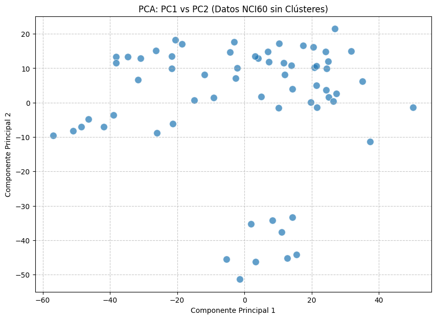

```python
import matplotlib.pyplot as plt
import seaborn as sns
import pandas as pd

# Crear un DataFrame con las dos primeras componentes principales
df_pca_plot = pd.DataFrame(X_pca[:, :2], columns=['PC1', 'PC2'])

plt.figure(figsize=(10, 7))
sns.scatterplot(x='PC1', y='PC2', data=df_pca_plot, palette='viridis', s=100, alpha=0.7)
plt.title('PCA: PC1 vs PC2 (Datos NCI60 sin Clústeres)')
plt.xlabel('Componente Principal 1')
plt.ylabel('Componente Principal 2')
plt.grid(True, linestyle='--', alpha=0.7)
plt.show()
```

### Re-ejecución de PCA y Visualización de Varianza Explicada

### Paso 3: Reducción de dimensionalidad y varianza explicada

#### ¿Qué se va a hacer?

Se aplicará PCA al dataset NCI60 y se analizará la varianza explicada por cada componente principal.

#### ¿Por qué y para qué se hace?

Este paso permite reducir la dimensionalidad de los datos y entender cuánta información aporta cada componente, lo cual es útil antes de aplicar clustering jerárquico.

#### Resultados

Se obtienen los datos transformados a un nuevo espacio de componentes principales:

Además, se genera una gráfica que muestra:

- La varianza explicada por cada componente (barras).
- La varianza acumulada (línea).

```
Dimensiones de los datos originales: (64, 6830)
Dimensiones de los datos transformados por PCA: (64, 64)
```

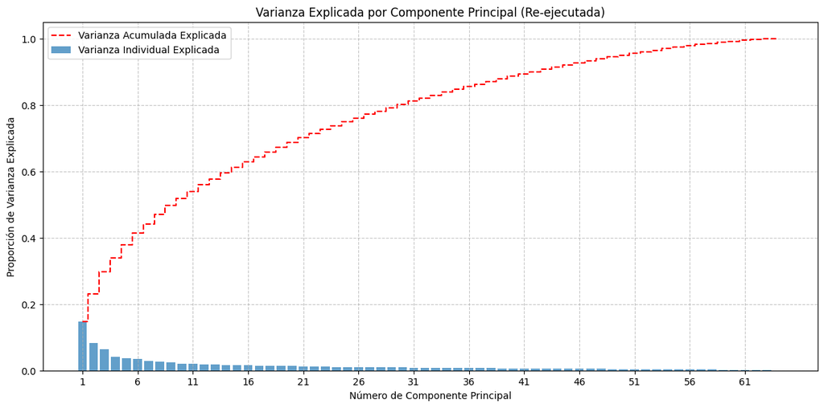

```python
from sklearn.decomposition import PCA
import matplotlib.pyplot as plt
import numpy as np

# Realizar PCA en los datos X_nci60_hierarchical
pca_new = PCA(n_components=None, random_state=42)
pca_new.fit(X_nci60_hierarchical)

# Transformar los datos
X_pca_new = pca_new.transform(X_nci60_hierarchical)

print(f"Dimensiones de los datos originales: {X_nci60_hierarchical.shape}")
print(f"Dimensiones de los datos transformados por PCA: {X_pca_new.shape}")

# Varianza explicada por cada componente
explained_variance_ratio_new = pca_new.explained_variance_ratio_
cumulative_explained_variance_new = np.cumsum(explained_variance_ratio_new)

plt.figure(figsize=(12, 6))

plt.bar(range(1, len(explained_variance_ratio_new) + 1), explained_variance_ratio_new, alpha=0.7, align='center', label='Varianza Individual Explicada')
plt.step(range(1, len(cumulative_explained_variance_new) + 1), cumulative_explained_variance_new, where='mid', label='Varianza Acumulada Explicada', color='red', linestyle='--')

plt.title('Varianza Explicada por Componente Principal (Re-ejecutada)')
plt.xlabel('Número de Componente Principal')
plt.ylabel('Proporción de Varianza Explicada')
plt.xticks(range(1, len(explained_variance_ratio_new) + 1, 5)) # Mostrar ticks cada 5 componentes
plt.grid(True, linestyle='--', alpha=0.7)
plt.legend()
plt.tight_layout()
plt.show()
```

### Paso 4: Visualización de datos reducidos con PCA

#### ¿Qué se va a hacer?

Se graficarán nuevamente las dos primeras componentes principales (PC1 y PC2) obtenidas del PCA aplicado al dataset.

#### ¿Por qué y para qué se hace?

Este paso permite visualizar los datos ya transformados, facilitando la identificación de posibles estructuras o agrupaciones antes de aplicar clustering jerárquico.

#### Resultados

Se obtiene una gráfica de dispersión donde cada punto representa una muestra en el espacio reducido.

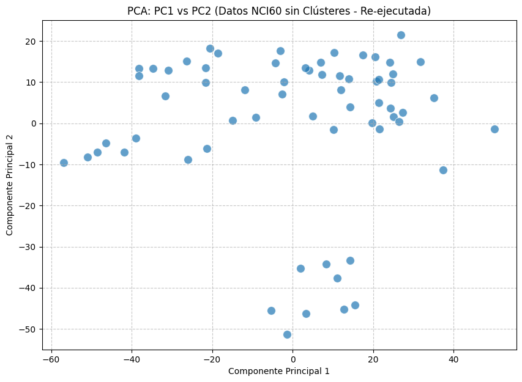

```python
import matplotlib.pyplot as plt
import seaborn as sns
import pandas as pd

# Crear un DataFrame con las dos primeras componentes principales del nuevo PCA
df_pca_new_plot = pd.DataFrame(X_pca_new[:, :2], columns=['PC1', 'PC2'])

plt.figure(figsize=(10, 7))
sns.scatterplot(x='PC1', y='PC2', data=df_pca_new_plot, palette='viridis', s=100, alpha=0.7)
plt.title('PCA: PC1 vs PC2 (Datos NCI60 sin Clústeres - Re-ejecutada)')
plt.xlabel('Componente Principal 1')
plt.ylabel('Componente Principal 2')
plt.grid(True, linestyle='--', alpha=0.7)
plt.show()
```

### Paso 5: Clustering jerárquico y dendrograma

#### ¿Qué se va a hacer?

Se aplicará clustering jerárquico utilizando los primeros componentes principales y se visualizará el resultado mediante un dendrograma.

#### ¿Por qué y para qué se hace?

Este paso permite analizar cómo se agrupan los datos de forma jerárquica, mostrando las relaciones entre las observaciones y cómo se van fusionando en clusters a diferentes niveles de distancia.

#### Resultados

Se utilizan los primeros 30 componentes principales para realizar el clustering jerárquico.

Se obtiene un dendrograma donde:

- Cada hoja representa una observación.
- Las ramas muestran cómo se agrupan los datos.
- La altura de las uniones indica la distancia entre clusters.

```
Se utilizarán los primeros 30 componentes principales para el clustering jerárquico.
Dimensiones de los datos para HCA: (64, 30)
```

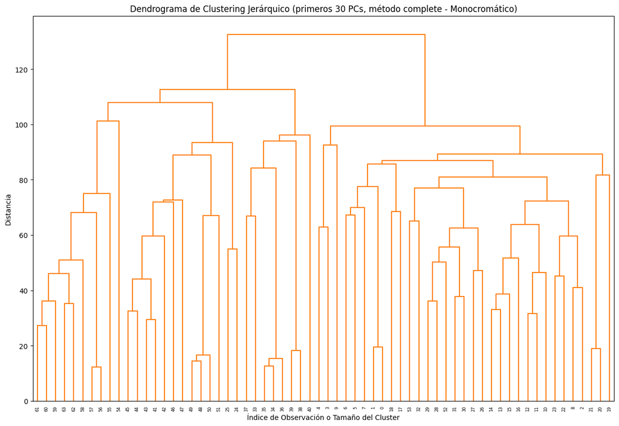

```python
from scipy.cluster.hierarchy import linkage, dendrogram, set_link_color_palette
import matplotlib.pyplot as plt
import numpy as np

# Decidir el número de componentes principales a utilizar
# Reutilizamos el número de componentes determinado anteriormente (30)
num_components_for_hca = 30
X_pca_hca = X_pca_new[:, :num_components_for_hca]

print(f"Se utilizarán los primeros {num_components_for_hca} componentes principales para el clustering jerárquico.")
print(f"Dimensiones de los datos para HCA: {X_pca_hca.shape}")

# Realizar clustering jerárquico
# Usamos el método 'complete' y la métrica 'euclidean' según lo solicitado.
linked_hca_complete = linkage(X_pca_hca, method='complete', metric='euclidean')

# Plotear el dendrograma
plt.figure(figsize=(15, 10))

# Para un dendrograma monocromático, podemos establecer un umbral de color alto
# y usar un solo color para las ramas por encima del umbral.
# set_link_color_palette(None) # Resetear paleta de colores si fue establecida antes
dendrogram(linked_hca_complete,
           orientation='top',
           distance_sort='descending',
           show_leaf_counts=True,
           color_threshold=np.inf, # Establece un umbral de color muy alto
           above_threshold_color='black') # Colorea todas las ramas de negro

plt.title(f'Dendrograma de Clustering Jerárquico (primeros {num_components_for_hca} PCs, método complete - Monocromático)')
plt.xlabel('Índice de Observación o Tamaño del Cluster')
plt.ylabel('Distancia')
plt.show()
```

### Paso 6: Identificación de 2 clusters en el dendrograma

#### ¿Qué se va a hacer?

Se calculará un umbral de corte en el dendrograma para resaltar la formación de 2 clusters.

#### ¿Por qué y para qué se hace?

Este paso permite definir explícitamente el número de clusters deseados, cortando el dendrograma en un nivel de distancia específico. Esto facilita la interpretación de los grupos formados.

#### Resultados

Se obtiene un dendrograma donde se destacan 2 clusters principales:

- Las ramas por debajo del umbral se agrupan en dos grandes conjuntos.
- Las conexiones por encima del umbral se muestran en un color distinto, indicando separaciones mayores.

Se observa que los datos pueden dividirse en dos grupos principales relativamente bien diferenciados. Este corte permite simplificar la estructura jerárquica en una partición más interpretable.

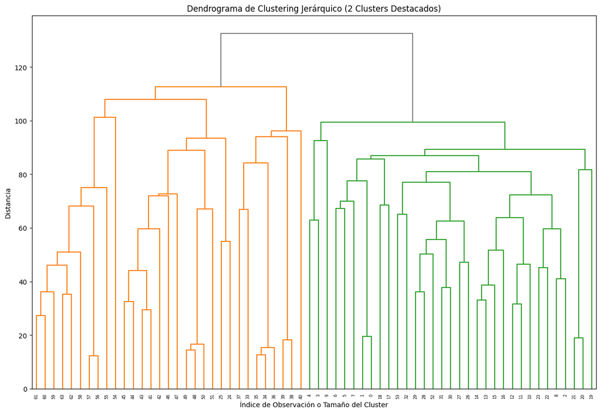

```python
# Calcular el umbral para 2 clusters
n_samples = len(X_pca_hca)
threshold_2_clusters = linked_hca_complete[n_samples - 2, 2]

plt.figure(figsize=(15, 10))
dendrogram(linked_hca_complete,
           orientation='top',
           distance_sort='descending',
           show_leaf_counts=True,
           color_threshold=threshold_2_clusters,
           above_threshold_color='gray') # Usar un color distinto para lo que está por encima del umbral

plt.title(f'Dendrograma de Clustering Jerárquico (2 Clusters Destacados)')
plt.xlabel('Índice de Observación o Tamaño del Cluster')
plt.ylabel('Distancia')
plt.show()
```

### Paso 7: Identificación de 3 clusters en el dendrograma

#### ¿Qué se va a hacer?

Se calculará un nuevo umbral de corte en el dendrograma para resaltar la formación de 3 clusters.

#### ¿Por qué y para qué se hace?

Este paso permite explorar una partición más detallada de los datos, evaluando si dividirlos en más grupos ofrece una mejor representación de su estructura.

#### Resultados

Se obtiene un dendrograma donde se destacan 3 clusters principales:

- Las ramas se agrupan en tres conjuntos diferenciados por debajo del umbral.
- Las uniones por encima del umbral indican separaciones más grandes entre estos grupos.

Se observa una división más granular de los datos en comparación con el caso de 2 clusters. Esto permite analizar con mayor detalle la estructura interna del dataset y comparar diferentes opciones de agrupamiento.

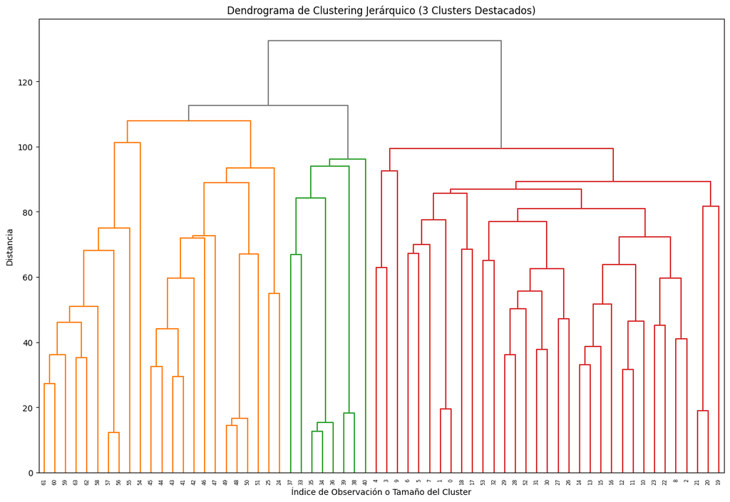

```python
# Calcular el umbral para 3 clusters
threshold_3_clusters = linked_hca_complete[n_samples - 3, 2]

plt.figure(figsize=(15, 10))
dendrogram(linked_hca_complete,
           orientation='top',
           distance_sort='descending',
           show_leaf_counts=True,
           color_threshold=threshold_3_clusters,
           above_threshold_color='gray')

plt.title(f'Dendrograma de Clustering Jerárquico (3 Clusters Destacados)')
plt.xlabel('Índice de Observación o Tamaño del Cluster')
plt.ylabel('Distancia')
plt.show()
```

### Paso 8: Identificación de 4 clusters en el dendrograma

#### ¿Qué se va a hacer?

Se calculará un umbral de corte en el dendrograma para visualizar la formación de 4 clusters.

#### ¿Por qué y para qué se hace?

Este paso permite analizar una partición más detallada del dataset, evaluando si una mayor cantidad de grupos representa mejor la estructura de los datos.

#### Resultados

Se obtiene un dendrograma donde se destacan 4 clusters principales:

- Los datos se dividen en cuatro grupos por debajo del umbral de corte.
- Las conexiones por encima del umbral representan separaciones más grandes entre los grupos.

Se observa una estructura más segmentada en comparación con los cortes anteriores. Esto ayuda a evaluar distintas posibles particiones y a entender mejor la complejidad del conjunto de datos bajo un enfoque jerárquico.

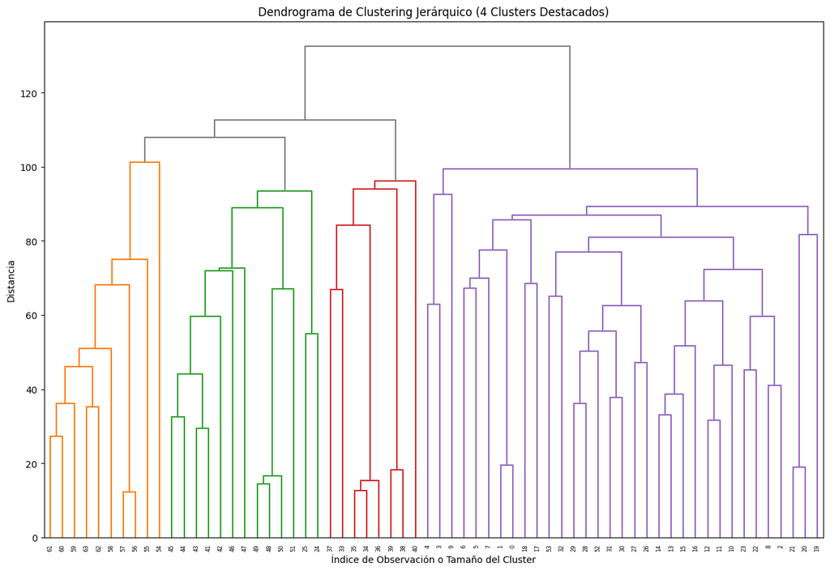

```python
# Calcular el umbral para 4 clusters
threshold_4_clusters = linked_hca_complete[n_samples - 4, 2]

plt.figure(figsize=(15, 10))
dendrogram(linked_hca_complete,
           orientation='top',
           distance_sort='descending',
           show_leaf_counts=True,
           color_threshold=threshold_4_clusters,
           above_threshold_color='gray')

plt.title(f'Dendrograma de Clustering Jerárquico (4 Clusters Destacados)')
plt.xlabel('Índice de Observación o Tamaño del Cluster')
plt.ylabel('Distancia')
plt.show()
```

### Paso 9: Clustering jerárquico con métrica de correlación

#### ¿Qué se va a hacer?

Se aplicará clustering jerárquico utilizando el método *complete* pero cambiando la métrica de distancia a *correlación*, y se visualizará mediante un dendrograma.

#### ¿Por qué y para qué se hace?

Este paso permite comparar cómo cambia la estructura de los clusters cuando se utiliza una métrica basada en correlación en lugar de distancia euclidiana. Esto puede revelar relaciones entre variables más enfocadas en su comportamiento relativo.

#### Resultados

Se genera un dendrograma monocromático que representa la jerarquía de agrupamiento de los datos.

Se observa la forma en que los clusters se forman considerando la similitud en patrones (correlación) en lugar de distancias absolutas. Esto puede producir agrupaciones diferentes a las obtenidas con la métrica euclidiana, mostrando otra perspectiva de la estructura del dataset.

```
Se utilizarán los primeros 30 componentes principales para el clustering jerárquico con métrica de correlación.
```

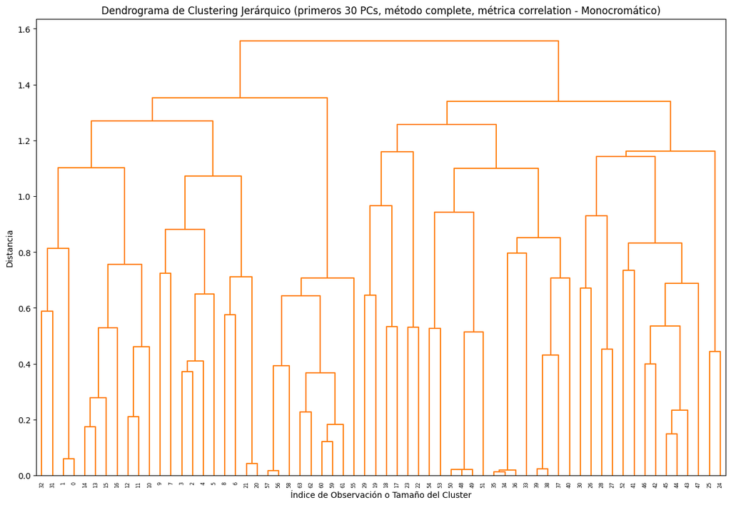

```python
from scipy.cluster.hierarchy import linkage, dendrogram
import matplotlib.pyplot as plt
import numpy as np

# Reutilizamos los primeros 30 componentes principales para el clustering jerárquico
# X_pca_hca ya está definido en celdas anteriores

print(f"Se utilizarán los primeros {num_components_for_hca} componentes principales para el clustering jerárquico con métrica de correlación.")

# Realizar clustering jerárquico con método 'complete' y métrica 'correlation'
linked_hca_correlation = linkage(X_pca_hca, method='complete', metric='correlation')

# Plotear el dendrograma monocromático
plt.figure(figsize=(15, 10))
dendrogram(linked_hca_correlation,
           orientation='top',
           distance_sort='descending',
           show_leaf_counts=True,
           color_threshold=np.inf, # Establece un umbral de color muy alto
           above_threshold_color='black') # Colorea todas las ramas de negro

plt.title(f'Dendrograma de Clustering Jerárquico (primeros {num_components_for_hca} PCs, método complete, métrica correlation - Monocromático)')
plt.xlabel('Índice de Observación o Tamaño del Cluster')
plt.ylabel('Distancia')
plt.show()
```

### Paso 10: Comparación de métricas en clustering jerárquico

#### ¿Qué se va a hacer?

Se construirán dos dendrogramas de clustering jerárquico utilizando el método *complete*, uno con métrica euclidiana y otro con métrica de correlación, y se compararán lado a lado.

#### ¿Por qué y para qué se hace?

Este paso permite analizar cómo cambia la estructura de los clusters dependiendo de la métrica utilizada. Comparar ambas visualizaciones ayuda a entender qué tipo de relación entre datos (distancia o correlación) describe mejor la estructura del dataset.

#### Resultados

Se obtienen dos dendrogramas:

- **Dendrograma con distancia euclidiana:** agrupa los datos en función de diferencias absolutas entre observaciones.
- **Dendrograma con correlación:** agrupa los datos según similitud en patrones de comportamiento.

Se observa que la estructura de los clusters puede variar entre ambas métricas, lo que indica que la forma en que se mide la similitud entre observaciones influye directamente en los resultados del clustering jerárquico. Esto permite elegir la métrica más adecuada según el tipo de análisis que se desea realizar.

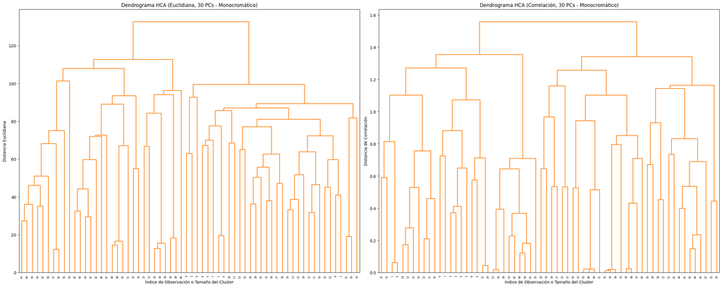

```python
from scipy.cluster.hierarchy import linkage, dendrogram
import matplotlib.pyplot as plt
import numpy as np

# Asegurarse de que X_pca_hca y num_components_for_hca estén disponibles
# (ya están definidos y procesados en celdas anteriores)

# Realizar clustering jerárquico con método 'complete' y métrica 'euclidean'
# Re-generar por si acaso el kernel ha sido reiniciado o variables limpiadas
linked_hca_complete = linkage(X_pca_hca, method='complete', metric='euclidean')

# Realizar clustering jerárquico con método 'complete' y métrica 'correlation'
linked_hca_correlation = linkage(X_pca_hca, method='complete', metric='correlation')

# Plotear ambos dendrogramas lado a lado
fig, axes = plt.subplots(1, 2, figsize=(25, 10), sharey=False)

# Dendrograma de Distancia Euclidiana (Monocromático)
plt.sca(axes[0]) # Seleccionar el primer subplot
dendrogram(linked_hca_complete,
           orientation='top',
           distance_sort='descending',
           show_leaf_counts=True,
           color_threshold=np.inf,
           above_threshold_color='black')
plt.title(f'Dendrograma HCA (Euclidiana, {num_components_for_hca} PCs - Monocromático)')
plt.xlabel('Índice de Observación o Tamaño del Cluster')
plt.ylabel('Distancia Euclidiana')

# Dendrograma de Métrica de Correlación (Monocromático)
plt.sca(axes[1]) # Seleccionar el segundo subplot
dendrogram(linked_hca_correlation,
           orientation='top',
           distance_sort='descending',
           show_leaf_counts=True,
           color_threshold=np.inf,
           above_threshold_color='black')
plt.title(f'Dendrograma HCA (Correlación, {num_components_for_hca} PCs - Monocromático)')
plt.xlabel('Índice de Observación o Tamaño del Cluster')
plt.ylabel('Distancia de Correlación')

plt.tight_layout()
plt.show()
```

### Paso 11: Clustering jerárquico con método average

#### ¿Qué se va a hacer?

Se aplicará clustering jerárquico utilizando el método *average* con métrica euclidiana, y se visualizará mediante un dendrograma.

#### ¿Por qué y para qué se hace?

Este paso permite comparar el comportamiento del clustering jerárquico usando un criterio de enlace diferente. El método *average* calcula la distancia promedio entre grupos, lo que puede generar estructuras más balanceadas.

#### Resultados

Se genera un dendrograma monocromático basado en los primeros 30 componentes principales.

Se observa cómo los clusters se forman de manera progresiva utilizando la distancia promedio entre grupos. En comparación con el método *complete*, este enfoque puede producir agrupaciones más suaves y menos sensibles a valores extremos, lo que ofrece una perspectiva diferente de la estructura del dataset.

```
Se utilizarán los primeros 30 componentes principales para el clustering jerárquico con método 'average' y métrica 'euclidean'.
```

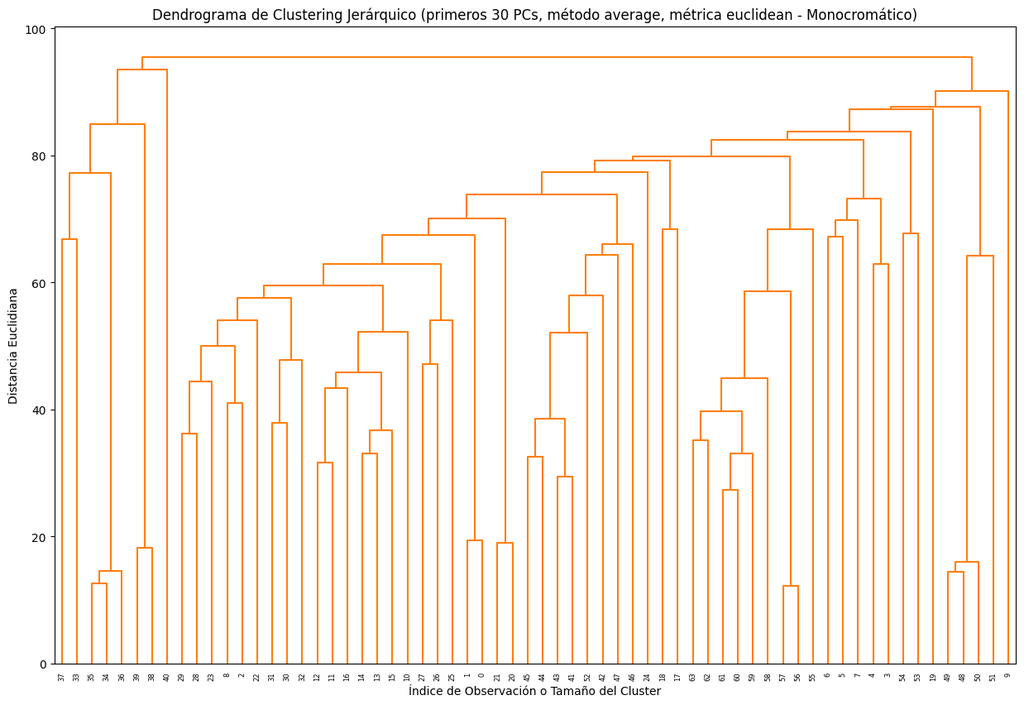

```python
from scipy.cluster.hierarchy import linkage, dendrogram
import matplotlib.pyplot as plt
import numpy as np

# Reutilizamos los primeros 30 componentes principales para el clustering jerárquico
# X_pca_hca ya está definido en celdas anteriores

print(f"Se utilizarán los primeros {num_components_for_hca} componentes principales para el clustering jerárquico con método 'average' y métrica 'euclidean'.")

# Realizar clustering jerárquico con método 'average' y métrica 'euclidean'
linked_hca_average = linkage(X_pca_hca, method='average', metric='euclidean')

# Plotear el dendrograma monocromático
plt.figure(figsize=(15, 10))
dendrogram(linked_hca_average,
           orientation='top',
           distance_sort='descending',
           show_leaf_counts=True,
           color_threshold=np.inf, # Establece un umbral de color muy alto
           above_threshold_color='black') # Colorea todas las ramas de negro

plt.title(f'Dendrograma de Clustering Jerárquico (primeros {num_components_for_hca} PCs, método average, métrica euclidean - Monocromático)')
plt.xlabel('Índice de Observación o Tamaño del Cluster')
plt.ylabel('Distancia Euclidiana')
plt.show()
```

### Paso 12: Comparación de métodos de clustering jerárquico

#### ¿Qué se va a hacer?

Se compararán tres dendrogramas generados con diferentes configuraciones de clustering jerárquico: método *complete* con distancia euclidiana, método *complete* con correlación y método *average* con distancia euclidiana.

#### ¿Por qué y para qué se hace?

Este paso permite analizar cómo cambian los resultados del clustering jerárquico dependiendo del método de enlace y la métrica utilizada. La comparación ayuda a identificar qué configuración produce una estructura más clara y coherente en los datos.

#### Resultados

La comparación muestra que no existe un único resultado de clustering jerárquico, sino que la estructura depende del método elegido. Esto es clave para interpretar correctamente los datos y seleccionar la configuración más adecuada según el objetivo del análisis.

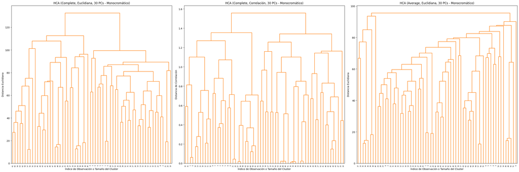

```python
from scipy.cluster.hierarchy import linkage, dendrogram
import matplotlib.pyplot as plt
import numpy as np

# Asegurarse de que X_pca_hca y num_components_for_hca estén disponibles
# (ya están definidos y procesados en celdas anteriores)

# linked_hca_complete y linked_hca_correlation ya fueron generados en celdas anteriores.
# linked_hca_average acaba de ser generado.

fig, axes = plt.subplots(1, 3, figsize=(30, 10), sharey=False)

# Dendrograma de Distancia Euclidiana (Método Complete)
plt.sca(axes[0]) # Seleccionar el primer subplot
dendrogram(linked_hca_complete,
           orientation='top',
           distance_sort='descending',
           show_leaf_counts=True,
           color_threshold=np.inf,
           above_threshold_color='black')
plt.title(f'HCA (Complete, Euclidiana, {num_components_for_hca} PCs - Monocromático)')
plt.xlabel('Índice de Observación o Tamaño del Cluster')
plt.ylabel('Distancia Euclidiana')

# Dendrograma de Métrica de Correlación (Método Complete)
plt.sca(axes[1]) # Seleccionar el segundo subplot
dendrogram(linked_hca_correlation,
           orientation='top',
           distance_sort='descending',
           show_leaf_counts=True,
           color_threshold=np.inf,
           above_threshold_color='black')
plt.title(f'HCA (Complete, Correlación, {num_components_for_hca} PCs - Monocromático)')
plt.xlabel('Índice de Observación o Tamaño del Cluster')
plt.ylabel('Distancia de Correlación')

# Dendrograma de Distancia Euclidiana (Método Average)
plt.sca(axes[2]) # Seleccionar el tercer subplot
dendrogram(linked_hca_average,
           orientation='top',
           distance_sort='descending',
           show_leaf_counts=True,
           color_threshold=np.inf,
           above_threshold_color='black')
plt.title(f'HCA (Average, Euclidiana, {num_components_for_hca} PCs - Monocromático)')
plt.xlabel('Índice de Observación o Tamaño del Cluster')
plt.ylabel('Distancia Euclidiana')

plt.tight_layout()
plt.show()
```

### Conclusión general de ambas actividades

En las dos actividades realizadas se aplicaron técnicas fundamentales de análisis no supervisado sobre datasets sintéticos y reales, combinando reducción de dimensionalidad (PCA) con distintos métodos de clustering (K-Means y clustering jerárquico).

En la primera actividad, se trabajó principalmente con datos sintéticos y K-Means. Esto permitió entender de forma clara el funcionamiento del algoritmo: cómo los datos se agrupan en función de la distancia a centroides, cómo estos se recalculan iterativamente y cómo la asignación de clusters mejora progresivamente. También se observó la importancia de la inicialización aleatoria y del uso de centroides para lograr una mejor separación de los datos.

En la segunda actividad, se trabajó con el dataset NCI60, un conjunto de datos reales de alta dimensionalidad. Aquí se utilizó PCA para reducir la complejidad de los datos y facilitar su interpretación, seguido de clustering jerárquico y K-Means sobre los componentes principales. Se exploraron diferentes métodos de enlace (complete y average) y diferentes métricas (euclidiana y correlación), lo que mostró que la estructura de los clusters puede variar significativamente según la configuración elegida. Además, el uso de dendrogramas permitió visualizar la jerarquía de agrupamiento y comparar distintas particiones.

En conjunto, ambas actividades demuestran que el análisis no supervisado depende fuertemente de la representación de los datos y del método utilizado. PCA ayuda a simplificar la información sin perder demasiada varianza, mientras que los métodos de clustering permiten descubrir estructuras ocultas. La interpretación final siempre debe basarse en la comparación de resultados y en la visualización, ya que no existe una única solución correcta, sino diferentes perspectivas del mismo conjunto de datos.

### Referencias

Scikit-learn developers. (2024). *Clustering*. In *scikit-learn user guide*. https://scikit-learn.org/stable/modules/clustering.html

Scikit-learn developers. (2024). *K-means clustering*. In *scikit-learn user guide*. https://scikit-learn.org/stable/modules/clustering.html#k-means

Scikit-learn developers. (2024). *Hierarchical clustering*. In *scikit-learn user guide*. https://scikit-learn.org/stable/modules/clustering.html#hierarchical-clustering

Esta actividad fue hecha con el apoyo de Gemini.